# Model Ensamble

Ballesteros

2023-03-22

Loading necessary packages: This block loads several R packages that are necessary for the analysis, such as class, caret, ggplot2, gmodels, neuralnet, glmnet, stringr, C50, and randomForest.

```r
library(class)
library(caret)
```

```r
library(ggplot2)
library(gmodels)
library(neuralnet)
library(glmnet)
library(stringr)
library(C50)
library(randomForest)
```

### Reading test data and renaming to normal data

Reading in test data: This block reads in the test dataset from a file called “tele_test” and stores it in a variable called tele_norm.

```r
tele_norm<- readRDS("tele_test")
```

### KNN Model

This block reads in the predictions from a k-nearest neighbors (KNN) model and stores them in a variable called knn_pred. Then it prints out the confusion matrix of the KNN model’s predictions against the true labels in tele_norm.

```r
knn_pred <- readRDS("knn_pred")

confusionMatrix(as.factor(knn_pred),as.factor(tele_norm$yyes))
```

```
## Confusion Matrix and Statistics
##
##           Reference
## Prediction     0     1
##          0 17598  1736
##          1   668   592
##
##                Accuracy : 0.8833
##                  95% CI : (0.8788, 0.8876)
##     No Information Rate : 0.887
##     P-Value [Acc > NIR] : 0.9534
##
##                   Kappa : 0.2722
##
##  Mcnemar's Test P-Value : <2e-16
##
##             Sensitivity : 0.9634
##             Specificity : 0.2543
##          Pos Pred Value : 0.9102
##          Neg Pred Value : 0.4698
##              Prevalence : 0.8870
##          Detection Rate : 0.8545
##    Detection Prevalence : 0.9388
##       Balanced Accuracy : 0.6089
##
##        'Positive' Class : 0
##
```

### KNN_reg

```r
knn_reg_pred <- readRDS("knn_reg_pred")

confusionMatrix(as.factor(ifelse(knn_reg_pred>0.17,1,0)),as.factor(tele_norm$yyes))
```

```
## Confusion Matrix and Statistics
##
##           Reference
## Prediction     0     1
##          0 15692  1038
##          1  2574  1290
##
##                Accuracy : 0.8246
##                  95% CI : (0.8193, 0.8298)
##     No Information Rate : 0.887
##     P-Value [Acc > NIR] : 1
##
##                   Kappa : 0.3208
##
##  Mcnemar's Test P-Value : <2e-16
##
##             Sensitivity : 0.8591
##             Specificity : 0.5541
##          Pos Pred Value : 0.9380
##          Neg Pred Value : 0.3339
##              Prevalence : 0.8870
##          Detection Rate : 0.7620
##    Detection Prevalence : 0.8124
##       Balanced Accuracy : 0.7066
##
##        'Positive' Class : 0
##
```

### ANN Model

This block reads in an artificial neural network (ANN) model and uses it to make predictions on tele_norm, which are stored in a variable called ann_pred. Then it prints out the confusion matrix of the ANN model’s predictions against the true labels in tele_norm.

```r
ann_model <- readRDS("ann_model.RDS")

ann_pred <- predict(ann_model ,tele_norm)

confusionMatrix(as.factor(ifelse(ann_pred>0.25,1,0)),as.factor(tele_norm$yyes))
```

```
## Confusion Matrix and Statistics
##
##           Reference
## Prediction     0     1
##          0 17095  1191
##          1  1171  1137
##
##                Accuracy : 0.8853
##                  95% CI : (0.8809, 0.8896)
##     No Information Rate : 0.887
##     P-Value [Acc > NIR] : 0.7765
##
##                   Kappa : 0.4259
##
##  Mcnemar's Test P-Value : 0.6958
##
##             Sensitivity : 0.9359
##             Specificity : 0.4884
##          Pos Pred Value : 0.9349
##          Neg Pred Value : 0.4926
##              Prevalence : 0.8870
##          Detection Rate : 0.8301
##    Detection Prevalence : 0.8879
##       Balanced Accuracy : 0.7121
##
##        'Positive' Class : 0
##
```

```r
plot(ann_model)
```

[output not shown]

### Logit model

This block reads in a logistic regression model and uses it to make predictions on tele_norm, which are stored in a variable called logit_pred. Then it prints out the confusion matrix of the logistic regression model’s predictions against the true labels in tele_norm.

```r
logit_model<-readRDS("logit_model")

logit_pred<-predict(logit_model, tele_norm , type = "response")
confusionMatrix(as.factor(ifelse(logit_pred>.5,1,0)),as.factor(tele_norm$yyes))
```

```
## Confusion Matrix and Statistics
##
##           Reference
## Prediction     0     1
##          0 18011  1806
##          1   255   522
##
##                Accuracy : 0.8999
##                  95% CI : (0.8957, 0.904)
##     No Information Rate : 0.887
##     P-Value [Acc > NIR] : 1.225e-09
##
##                   Kappa : 0.2964
##
##  Mcnemar's Test P-Value : < 2.2e-16
##
##             Sensitivity : 0.9860
##             Specificity : 0.2242
##          Pos Pred Value : 0.9089
##          Neg Pred Value : 0.6718
##              Prevalence : 0.8870
##          Detection Rate : 0.8746
##    Detection Prevalence : 0.9623
##       Balanced Accuracy : 0.6051
##
##        'Positive' Class : 0
##
```

### Decision Tree

This block reads in a decision tree model and uses it to make predictions on tele_norm, which are stored in a variable called DT_pred. Then it prints out the confusion matrix of the decision tree model’s predictions against the true labels in tele_norm.

```r
DT_model <- readRDS("DT_model")

DT_pred <- as.numeric(predict(DT_model, tele_norm))-1

confusionMatrix(as.factor(DT_pred),as.factor(tele_norm$yyes))
```

```
## Confusion Matrix and Statistics
##
##           Reference
## Prediction     0     1
##          0 17652  1555
##          1   614   773
##
##                Accuracy : 0.8947
##                  95% CI : (0.8904, 0.8988)
##     No Information Rate : 0.887
##     P-Value [Acc > NIR] : 0.0002151
##
##                   Kappa : 0.3623
##
##  Mcnemar's Test P-Value : < 2.2e-16
##
##             Sensitivity : 0.9664
##             Specificity : 0.3320
##          Pos Pred Value : 0.9190
##          Neg Pred Value : 0.5573
##              Prevalence : 0.8870
##          Detection Rate : 0.8571
##    Detection Prevalence : 0.9327
##       Balanced Accuracy : 0.6492
##
##        'Positive' Class : 0
##
```

### Boosted Decision Tree

This block reads in a boosted decision tree model and uses it to make predictions on tele_norm, which are stored in a variable called DT_pred_boost. Then it prints out the confusion matrix of the boosted decision tree model’s predictions against the true labels in tele_norm.

```r
DT_model_boost <- readRDS("DT_model_boost")

DT_pred_boost <- as.numeric(predict(DT_model_boost, tele_norm))-1

confusionMatrix(as.factor(DT_pred_boost),as.factor(tele_norm$yyes))
```

```
## Confusion Matrix and Statistics
##
##           Reference
## Prediction     0     1
##          0 17954  1782
##          1   312   546
##
##                Accuracy : 0.8983
##                  95% CI : (0.8941, 0.9024)
##     No Information Rate : 0.887
##     P-Value [Acc > NIR] : 9.235e-08
##
##                   Kappa : 0.3001
##
##  Mcnemar's Test P-Value : < 2.2e-16
##
##             Sensitivity : 0.9829
##             Specificity : 0.2345
##          Pos Pred Value : 0.9097
##          Neg Pred Value : 0.6364
##              Prevalence : 0.8870
##          Detection Rate : 0.8718
##    Detection Prevalence : 0.9583
##       Balanced Accuracy : 0.6087
##
##        'Positive' Class : 0
##
```

### Support Vector Machines

This block reads in several support vector machine (SVM) models and uses them to make predictions on tele_norm. The predictions are stored in a data frame called SVM_df, which is then saved to a file called “svm_pred”.

```r
SVMs <- readRDS("svms")

SVM_df <- data.frame(rbfdot = predict(SVMs$rbfdot,tele_test))

SVM_df$polydot    <- predict(SVMs$polydot,tele_norm)
SVM_df$tanhdot    <- predict(SVMs$tanhdot,tele_norm)
SVM_df$vanilladot <- predict(SVMs$vanilladot,tele_norm)
SVM_df$laplacedot <- predict(SVMs$laplacedot,tele_norm)
SVM_df$besseldot  <- predict(SVMs$besseldot,tele_norm)
SVM_df$anovadot   <- predict(SVMs$anovadot,tele_norm)
SVM_df$splinedot  <- predict(SVMs$splinedot,tele_norm)

saveRDS(SVM_df, "svm_pred")
```

This block reads in the svm_pred variable and checks if there is any perfect multicollinearity between the regressors and then drops polydot as it seems to have a perfect multicollinearity problem with vanilladot

```r
SVM_df<-readRDS("svm_pred")

SVM_df<-as.data.frame(lapply(SVM_df,as.numeric))

cor(SVM_df)
```

```
##                 rbfdot     polydot     tanhdot  vanilladot  laplacedot
## rbfdot      1.00000000  0.82711870  0.24690558  0.82711870  0.82787228
## polydot     0.82711870  1.00000000  0.23826056  1.00000000  0.96508839
## tanhdot     0.24690558  0.23826056  1.00000000  0.23826056  0.22954255
## vanilladot  0.82711870  1.00000000  0.23826056  1.00000000  0.96508839
## laplacedot  0.82787228  0.96508839  0.22954255  0.96508839  1.00000000
## besseldot  -0.06177379 -0.06627843 -0.11579280 -0.06627843 -0.06396455
## anovadot    0.84371166  0.97430677  0.23481388  0.97430677  0.94029215
## splinedot   0.11628260  0.14964621  0.05813695  0.14964621  0.14566905
##              besseldot    anovadot   splinedot
## rbfdot     -0.06177379  0.84371166  0.11628260
## polydot    -0.06627843  0.97430677  0.14964621
## tanhdot    -0.11579280  0.23481388  0.05813695
## vanilladot -0.06627843  0.97430677  0.14964621
## laplacedot -0.06396455  0.94029215  0.14566905
## besseldot   1.00000000 -0.06802625 -0.04826574
## anovadot   -0.06802625  1.00000000  0.14910675
## splinedot  -0.04826574  0.14910675  1.00000000
```

```r
SVM_df$polydot <- NULL
```

### Random Forest

his block reads in a random forest model and uses it to make predictions on tele_norm, which are stored in a variable called RF_pred. Then it prints out the confusion matrix of the random forest model’s predictions against the true labels in tele_norm.

```r
RF_model <- readRDS("RF_model")

RF_pred <- as.numeric(predict(RF_model, tele_norm))-1

confusionMatrix(as.factor(RF_pred),as.factor(tele_norm$yyes))
```

```
## Confusion Matrix and Statistics
##
##           Reference
## Prediction     0     1
##          0 16442  1012
##          1  1824  1316
##
##                Accuracy : 0.8623
##                  95% CI : (0.8575, 0.867)
##     No Information Rate : 0.887
##     P-Value [Acc > NIR] : 1
##
##                   Kappa : 0.404
##
##  Mcnemar's Test P-Value : <2e-16
##
##             Sensitivity : 0.9001
##             Specificity : 0.5653
##          Pos Pred Value : 0.9420
##          Neg Pred Value : 0.4191
##              Prevalence : 0.8870
##          Detection Rate : 0.7984
##    Detection Prevalence : 0.8475
##       Balanced Accuracy : 0.7327
##
##        'Positive' Class : 0
##
```

### Combined Data Frame

Combining all predictions from all prior models into a single data frame for later use in the level two model

```r
df_2 <- data.frame(knn_pred,
                   knn_reg_pred,
                   ann_pred,
                   logit_pred,
                   DT_pred,
                   DT_pred_boost,
                   RF_pred,
                   yyes= tele_norm$yyes)

df_2 <- data.frame(df_2,SVM_df)
```

### Test and Train

Spliting data into test and train data

```r
set.seed(12345)
test_set <- sample(1:nrow(df_2), nrow(df_2)*0.3)

df_2_train <- df_2[-test_set,]
df_2_test  <- df_2[test_set,]
```

### UpSample Train Data

Upsampling train data for use in some random forest and decision tree models

```r
df_2_up_train <- upSample(df_2_train[, !names(df_2_train) %in% "yyes"],as.factor(df_2_train$yyes), yname = "yyes")
```

### Final Decision Tree

This is the final decision tree model utilizing the df_2 dataset created above to improve prediction

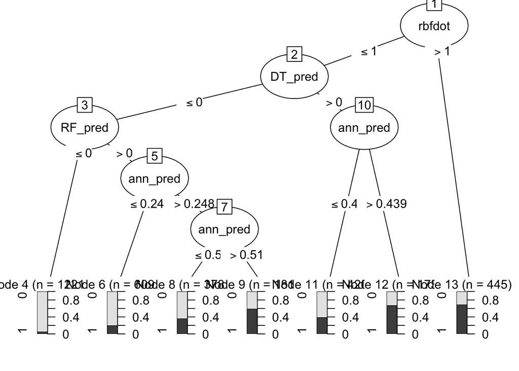

```r
DT_model_2 <- C5.0(as.factor(yyes) ~ ., data = df_2_train)

plot(DT_model_2)
```

```r
DT_pred_2 <- as.factor(predict(DT_model_2, df_2_test))
```

```r
confusionMatrix(DT_pred_2,as.factor(df_2_test$yyes))
```

```
## Confusion Matrix and Statistics
##
##           Reference
## Prediction    0    1
##          0 5390  424
##          1  132  232
##
##                Accuracy : 0.91
##                  95% CI : (0.9026, 0.917)
##     No Information Rate : 0.8938
##     P-Value [Acc > NIR] : 1.325e-05
##
##                   Kappa : 0.4102
##
##  Mcnemar's Test P-Value : < 2.2e-16
##
##             Sensitivity : 0.9761
##             Specificity : 0.3537
##          Pos Pred Value : 0.9271
##          Neg Pred Value : 0.6374
##              Prevalence : 0.8938
##          Detection Rate : 0.8725
##    Detection Prevalence : 0.9411
##       Balanced Accuracy : 0.6649
##
##        'Positive' Class : 0
##
```

### Cost Matrix DT

```r
error_cost <- matrix(c(0,0,-20,0),nrow = 2)
error_cost
```

```
##      [,1] [,2]
## [1,]    0  -20
## [2,]    0    0
```

```r
DT_2_errorcost <- C5.0(as.factor(yyes) ~ ., data = df_2_train, costs = error_cost)
errorcost_pred <- predict(DT_2_errorcost, df_2_test)

confusionMatrix(as.factor(errorcost_pred), as.factor(df_2_test$yyes))
```

```
## Confusion Matrix and Statistics
##
##           Reference
## Prediction    0    1
##          0 5390  424
##          1  132  232
##
##                Accuracy : 0.91
##                  95% CI : (0.9026, 0.917)
##     No Information Rate : 0.8938
##     P-Value [Acc > NIR] : 1.325e-05
##
##                   Kappa : 0.4102
##
##  Mcnemar's Test P-Value : < 2.2e-16
##
##             Sensitivity : 0.9761
##             Specificity : 0.3537
##          Pos Pred Value : 0.9271
##          Neg Pred Value : 0.6374
##              Prevalence : 0.8938
##          Detection Rate : 0.8725
##    Detection Prevalence : 0.9411
##       Balanced Accuracy : 0.6649
##
##        'Positive' Class : 0
##
```

### Boosting

Implementing 10 boosting trials to try and see if prediction error goes down

```r
DT_2_boosted <- C5.0(as.factor(yyes) ~ ., data = df_2_train, trials = 10)

#plot(DT_2_boosted)

boosted_pred <- predict(DT_2_boosted,df_2_test)

confusionMatrix(as.factor(boosted_pred), as.factor(df_2_test$yyes))
```

```
## Confusion Matrix and Statistics
##
##           Reference
## Prediction    0    1
##          0 5402  446
##          1  120  210
##
##                Accuracy : 0.9084
##                  95% CI : (0.9009, 0.9155)
##     No Information Rate : 0.8938
##     P-Value [Acc > NIR] : 8.184e-05
##
##                   Kappa : 0.382
##
##  Mcnemar's Test P-Value : < 2.2e-16
##
##             Sensitivity : 0.9783
##             Specificity : 0.3201
##          Pos Pred Value : 0.9237
##          Neg Pred Value : 0.6364
##              Prevalence : 0.8938
##          Detection Rate : 0.8744
##    Detection Prevalence : 0.9466
##       Balanced Accuracy : 0.6492
##
##        'Positive' Class : 0
##
```

### Combining boosting and error cost matrix

```r
DT_2_boosted_error <- C5.0(as.factor(yyes) ~ ., data = df_2_train, trials = 20, costs = error_cost)
```

```r
#plot(DT_2_boosted)

boosted_error_pred <- predict(DT_2_boosted_error,df_2_test)

confusionMatrix(as.factor(boosted_error_pred), as.factor(df_2_test$yyes))
```

```
## Confusion Matrix and Statistics
##
##           Reference
## Prediction    0    1
##          0 5397  472
##          1  125  184
##
##                Accuracy : 0.9034
##                  95% CI : (0.8957, 0.9106)
##     No Information Rate : 0.8938
##     P-Value [Acc > NIR] : 0.007277
##
##                   Kappa : 0.3362
##
##  Mcnemar's Test P-Value : < 2.2e-16
##
##             Sensitivity : 0.9774
##             Specificity : 0.2805
##          Pos Pred Value : 0.9196
##          Neg Pred Value : 0.5955
##              Prevalence : 0.8938
##          Detection Rate : 0.8736
##    Detection Prevalence : 0.9500
##       Balanced Accuracy : 0.6289
##
##        'Positive' Class : 0
##
```

### Combined Logit

Running a logit regression to see if prediction improves

```r
logit_comb<- glm(yyes~., df_2_train, family = "binomial")

logit_comb_pred<-predict(logit_comb, df_2_test , type = "response")

pred<-as.factor(ifelse(logit_comb_pred>=.16,1,0))

confusionMatrix(pred,as.factor(df_2_test$yyes), positive = "1")
```

```
## Confusion Matrix and Statistics
##
##           Reference
## Prediction    0    1
##          0 4949  278
##          1  573  378
##
##                Accuracy : 0.8623
##                  95% CI : (0.8534, 0.8708)
##     No Information Rate : 0.8938
##     P-Value [Acc > NIR] : 1
##
##                   Kappa : 0.3943
##
##  Mcnemar's Test P-Value : <2e-16
##
##             Sensitivity : 0.57622
##             Specificity : 0.89623
##          Pos Pred Value : 0.39748
##          Neg Pred Value : 0.94681
##              Prevalence : 0.10618
##          Detection Rate : 0.06118
##    Detection Prevalence : 0.15393
##       Balanced Accuracy : 0.73623
##
##        'Positive' Class : 1
##
```

```r
summary(logit_comb)
```

```
##
## Call:
## glm(formula = yyes ~ ., family = "binomial", data = df_2_train)
##
## Deviance Residuals:
##     Min       1Q   Median       3Q      Max
## -2.0990  -0.3552  -0.3422  -0.3327   2.6632
##
## Coefficients:
##               Estimate Std. Error z value Pr(>|z|)
## (Intercept)   -1.86946    0.27589  -6.776 1.23e-11 ***
## knn_pred1      0.06136    0.10819   0.567 0.570588
## knn_reg_pred   0.44054    0.33657   1.309 0.190571
## ann_pred       2.79224    0.27314  10.223  < 2e-16 ***
## logit_pred     1.93029    0.43771   4.410 1.03e-05 ***
## DT_pred        0.19830    0.12633   1.570 0.116497
## DT_pred_boost -0.04951    0.17053  -0.290 0.771571
## RF_pred        0.76928    0.11152   6.898 5.27e-12 ***
## rbfdot        -0.81918    0.22926  -3.573 0.000353 ***
## tanhdot       -0.05138    0.09459  -0.543 0.587032
## vanilladot    -2.66351    0.71396  -3.731 0.000191 ***
## laplacedot    -0.03845    0.40989  -0.094 0.925259
## besseldot     -0.63680    0.15592  -4.084 4.42e-05 ***
## anovadot       3.06887    0.60855   5.043 4.59e-07 ***
## splinedot     -0.03514    0.07476  -0.470 0.638295
## ---
## Signif. codes:  0 '***' 0.001 '**' 0.01 '*' 0.05 '.' 0.1 ' ' 1
##
## (Dispersion parameter for binomial family taken to be 1)
##
##     Null deviance: 10346.2  on 14415  degrees of freedom
## Residual deviance:  7942.7  on 14401  degrees of freedom
## AIC: 7972.7
##
## Number of Fisher Scoring iterations: 6
```

### Combined Random Forest

Combined

```r
RF_model_2 <- randomForest(as.factor(yyes)~.,data = df_2_up_train)

RF_pred_2 <- as.numeric(predict(RF_model_2, df_2_test))-1

confusionMatrix(as.factor(RF_pred_2), as.factor(df_2_test$yyes))
```

```
## Confusion Matrix and Statistics
##
##           Reference
## Prediction    0    1
##          0 4829  261
##          1  693  395
##
##                Accuracy : 0.8456
##                  95% CI : (0.8363, 0.8545)
##     No Information Rate : 0.8938
##     P-Value [Acc > NIR] : 1
##
##                   Kappa : 0.3694
##
##  Mcnemar's Test P-Value : <2e-16
##
##             Sensitivity : 0.8745
##             Specificity : 0.6021
##          Pos Pred Value : 0.9487
##          Neg Pred Value : 0.3631
##              Prevalence : 0.8938
##          Detection Rate : 0.7816
##    Detection Prevalence : 0.8239
##       Balanced Accuracy : 0.7383
##
##        'Positive' Class : 0
##
```

### Conclusion

The best model was the ANN model with c(4,2) hidden layers. It managed to get a kappa of 0.425 which is remarkable given that the best-combined model could only achieve a kappa of 0.4102. It is hard for me to fully understand why this is the case, but I suspect it has to do with how much data it was trained on. Because the first model had the availability of 50% of the data to train with, it is possible that due to the nature of ANN, which tends to continue to learn linearly as new data is implemented, it performed better than the decision tree of all the outputs of the data.

From the first stage models, the order of the models regarding their kappa is ANN, RF, DT, KNN-reg, Logit, and KNN. These models all have a more complex problem estimating false negatives than false positives, which means they tend to predict that individuals will not buy when called more than they will expect that they won’t buy when indeed they will. Notably, the logit model and the DT Boosted model were both the best at reducing the number of false positives, that is to say, when we believe someone will buy when they would not. The best overall balanced model was the ANN model, which showed a roughly equal amount of false positives and false negatives.

Compared to the second stage models, which I believe should be worth comparison, the Combined DT preferred false negatives, while the logit preferred false positives. These results are suggestive that there is probably a possibility for a third-stage model that will still slightly better predict outcomes. Given that neither of these models outperformed the first stage ANN I would be hesitant to use either given their increased complexity and likelihood of overfitting, instead opting for increasing the amount of training data for the ANN and applying cross-validation techniques